# Homework4-5

```r
data_path = "C:/Users/User/Desktop/ie360/hwson/ProjectRawData.csv"
daily_data = fread(data_path)
str(daily_data)
```

```
## Classes 'data.table' and 'data.frame':   4331 obs. of  13 variables:
##  $ event_date         : IDate, format: "2021-05-31" "2021-05-31" ...
##  $ product_content_id : int  85004 4066298 6676673 7061886 31515569 32737302 32939029 48740784 73318567 85004 ...
##  $ price              : num  87.4 65.8 120.7 294.4 60.3 ...
##  $ sold_count         : int  80 1398 345 24 454 44 125 2 175 85 ...
##  $ visit_count        : int  6002 19102 19578 1485 20114 5017 5301 221 20256 5265 ...
##  $ basket_count       : int  744 5096 1261 81 2871 316 608 15 965 633 ...
##  $ favored_count      : int  1642 1703 1510 122 2102 607 698 22 1960 1104 ...
##  $ category_sold      : int  5048 6547 4944 951 8155 5198 930 1684 5198 4117 ...
##  $ category_visits    : int  236197 108811 306462 95645 637143 1010634 41973 329087 1010634 215260 ...
##  $ category_basket    : int  33681 28558 23418 4704 49389 33728 3911 12614 33728 25181 ...
##  $ category_favored   : int  40472 11913 26597 8886 62460 96699 5791 24534 96699 36225 ...
##  $ category_brand_sold: int  743 4286 786 179 1759 3665 875 12 3665 430 ...
##  $ ty_visits          : int  125439876 125439876 125439876 125439876 125439876 125439876 125439876 125439876 125439876 131821083 ...
##  - attr(*, ".internal.selfref")=<externalptr>
```

```r
daily_data$event_date <- as.Date(daily_data$event_date, "%d.%m.%Y")
```

We divided ‘daily_data’ into different data tables in terms of products to examine and understand more easily in the future parts.

```r
product1_data <- daily_data[product_content_id == 48740784]
product2_data <- daily_data[product_content_id == 73318567]
product3_data <- daily_data[product_content_id == 32737302]
product4_data <- daily_data[product_content_id == 31515569]
product5_data <- daily_data[product_content_id == 6676673]
product6_data <- daily_data[product_content_id == 7061886]
product7_data <- daily_data[product_content_id == 85004]
product8_data <- daily_data[product_content_id == 4066298]
product9_data <- daily_data[product_content_id == 32939029]
```

## ANALYSIS of Product1

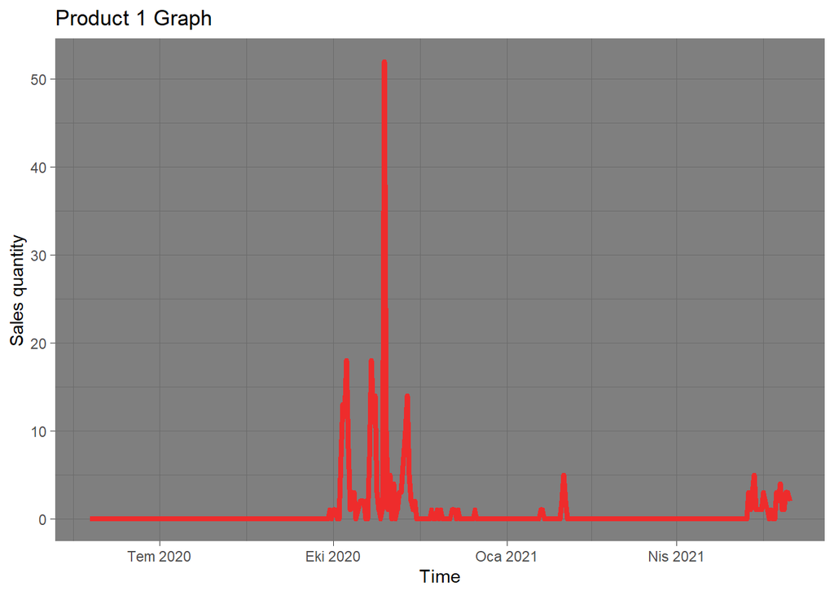

```r
ggplot(product1_data, aes(x = event_date, y = sold_count)) +
    geom_line(colour = "firebrick2", size = 1.5) + labs(title = "Product 1 Graph",
    x = "Time", y = "Sales quantity") + theme_dark()
```

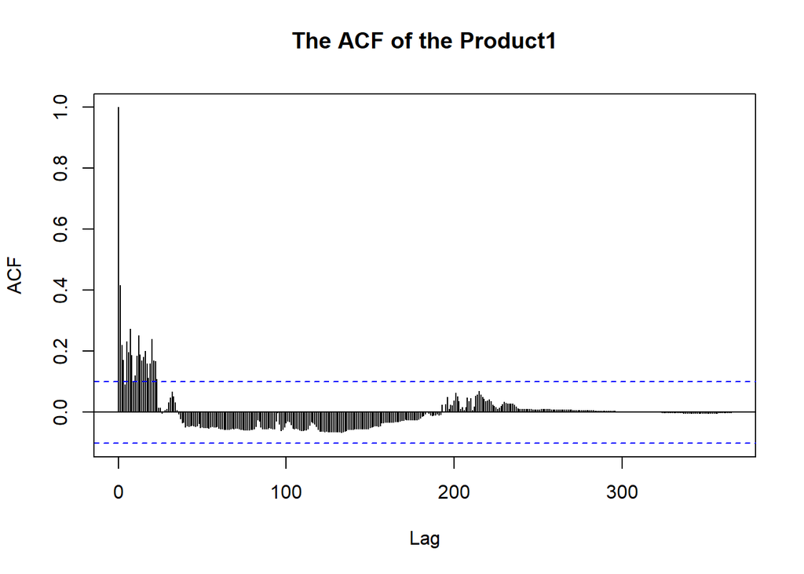

```r
acf(product1_data$sold_count, lag.max = 365, main = "The ACF of the Product1")
```

There are high autocorrelation values for some recent lags.There is no obvious trend but there may be a daily seasonality.

## ANALYSIS of Product2

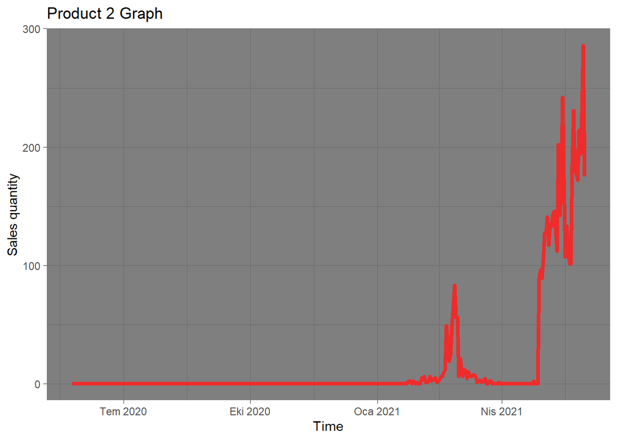

```r
ggplot(product2_data, aes(x = event_date, y = sold_count)) +
    geom_line(colour = "firebrick2", size = 1.5) + labs(title = "Product 2 Graph",
    x = "Time", y = "Sales quantity") + theme_dark()
```

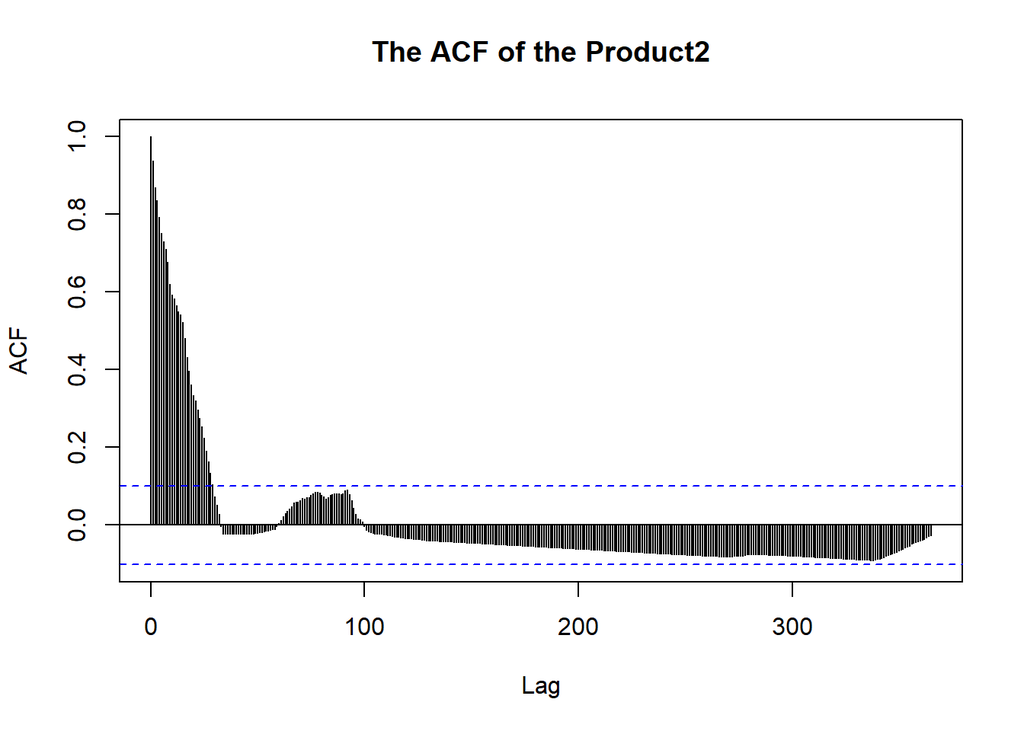

```r
acf(product2_data$sold_count, lag.max = 365, main = "The ACF of the Product2")
```

There are high and decreasing autocorrelation values for recent lags.Initially Decreasing autocorrelation values show us a trend.

## ANALYSIS of Product3

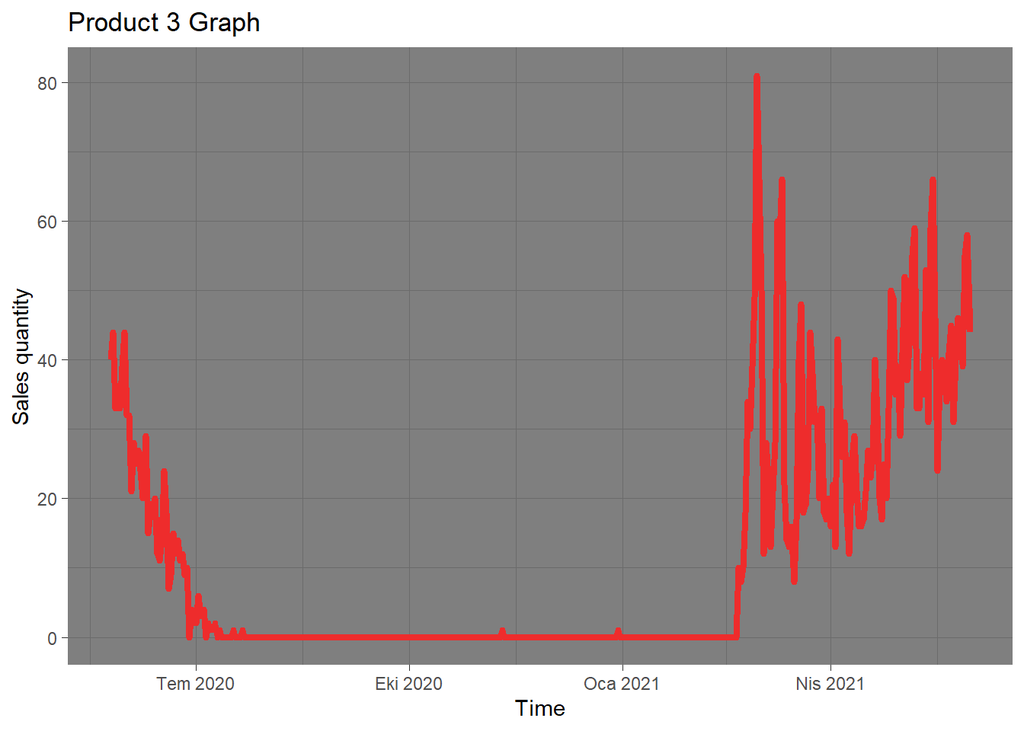

```r
ggplot(product3_data, aes(x = event_date, y = sold_count)) +
    geom_line(colour = "firebrick2", size = 1.5) + labs(title = "Product 3 Graph",
    x = "Time", y = "Sales quantity") + theme_dark()
```

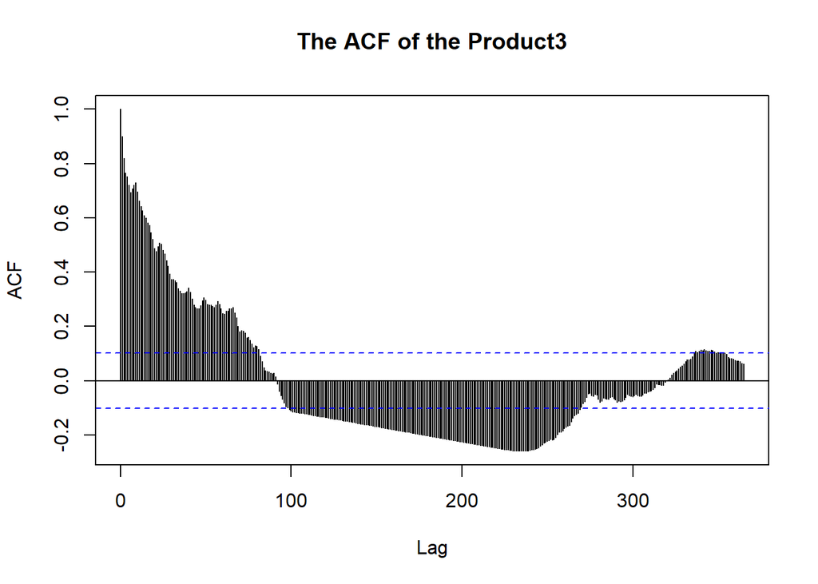

```r
acf(product3_data$sold_count, lag.max = 365, main = "The ACF of the Product3")
```

There are high and decreasing autocorrelation values for recent lags.Initially decreasing autocorrelation values show us a trend.While there is a downward trend between May 2020 and July 2020, there is a upward trend after March 2021.Since it is a product used in summer, sales start and increase before summer, and sales decrease towards the end of summer.

## ANALYSIS of Product4

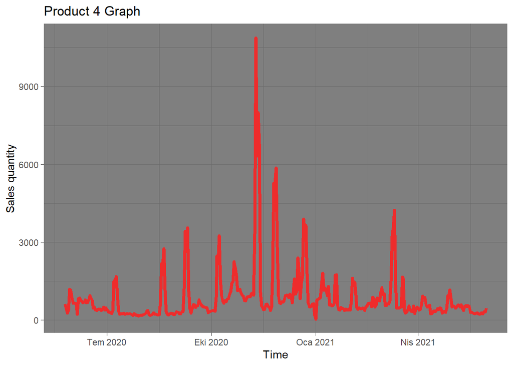

```r
ggplot(product4_data, aes(x = event_date, y = sold_count)) +
    geom_line(colour = "firebrick2", size = 1.5) + labs(title = "Product 4 Graph",
    x = "Time", y = "Sales quantity") + theme_dark()
```

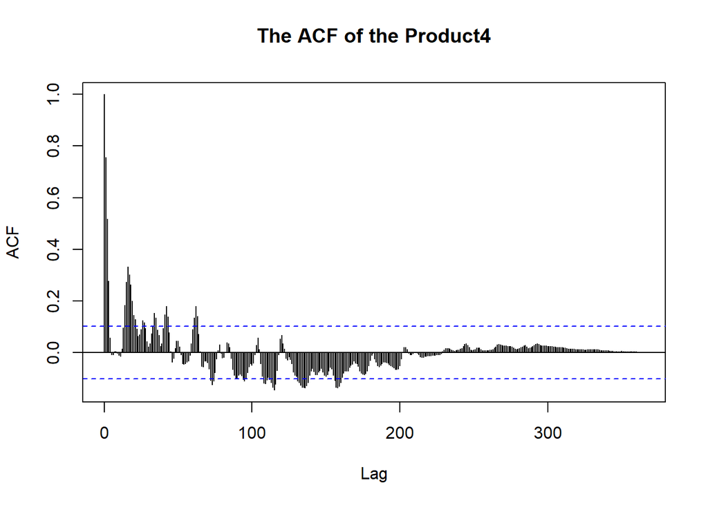

```r
acf(product4_data$sold_count, lag.max = 365, main = "The ACF of the Product4")
```

When we look at the acf chart of product4, there is a trend, although it is not as obvious as the trend in product2 and 3.The decrease in the initial lags indicates the trend, but since this decrease is only for a few lags, we understand that the trend in sales values is short-term.Also it may have weekly and monthly seasonality.

## ANALYSIS of Product5

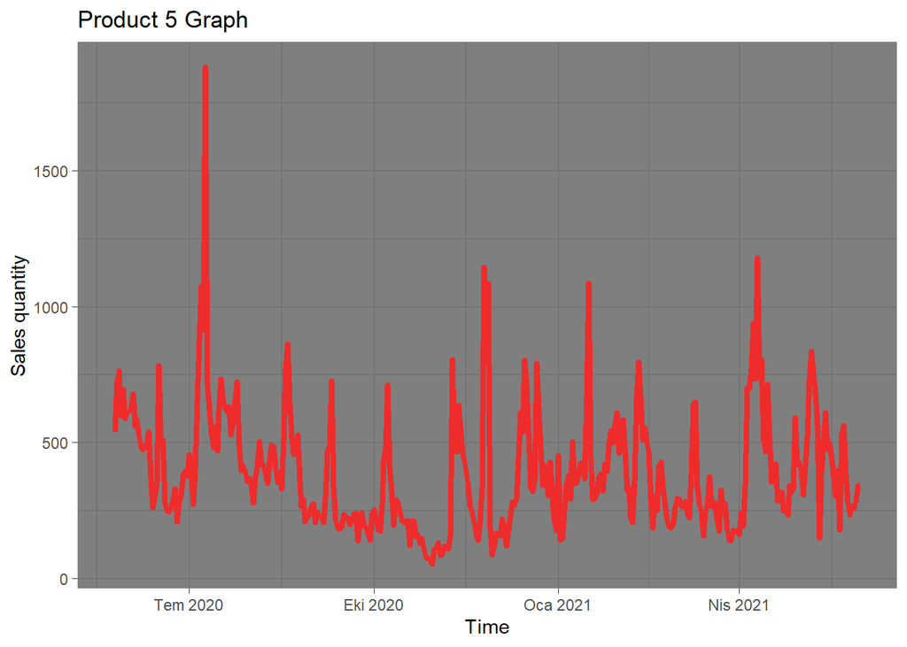

```r
ggplot(product5_data, aes(x = event_date, y = sold_count)) +
    geom_line(colour = "firebrick2", size = 1.5) + labs(title = "Product 5 Graph",
    x = "Time", y = "Sales quantity") + theme_dark()
```

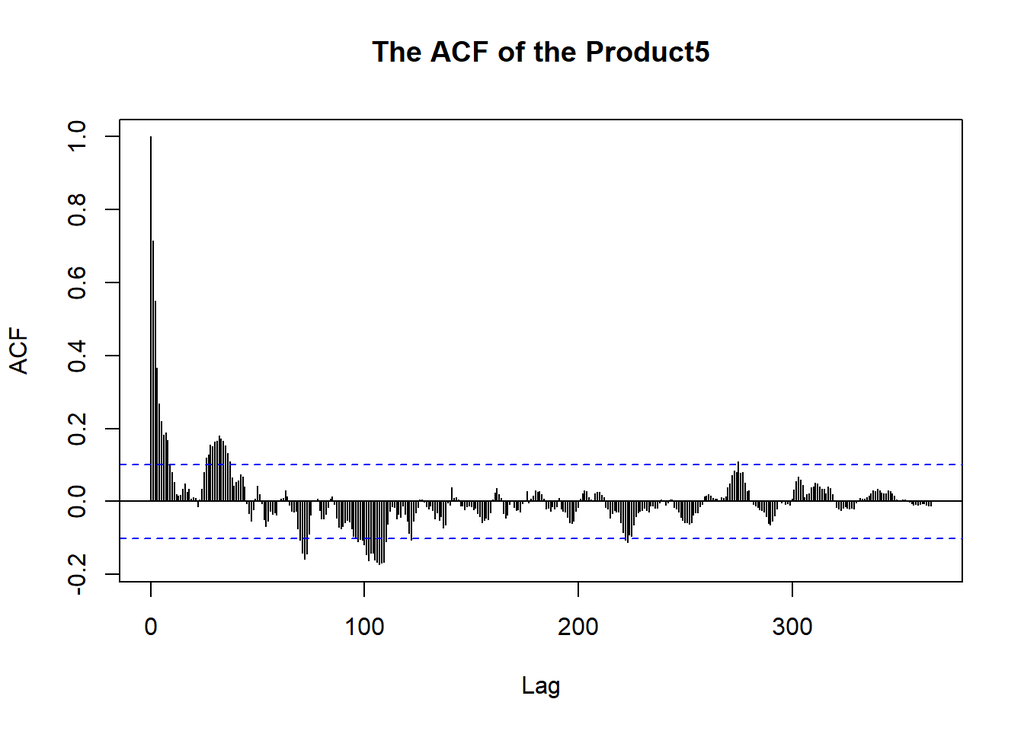

```r
acf(product5_data$sold_count, lag.max = 365, main = "The ACF of the Product5")
```

## ANALYSIS of Product6

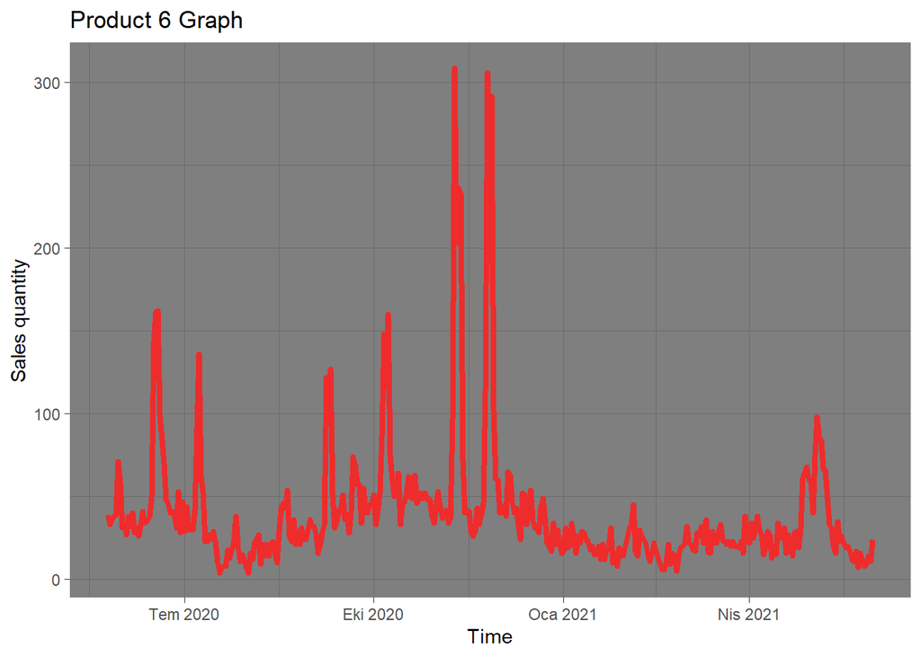

```r
ggplot(product6_data, aes(x = event_date, y = sold_count)) +
    geom_line(colour = "firebrick2", size = 1.5) + labs(title = "Product 6 Graph",
    x = "Time", y = "Sales quantity") + theme_dark()
```

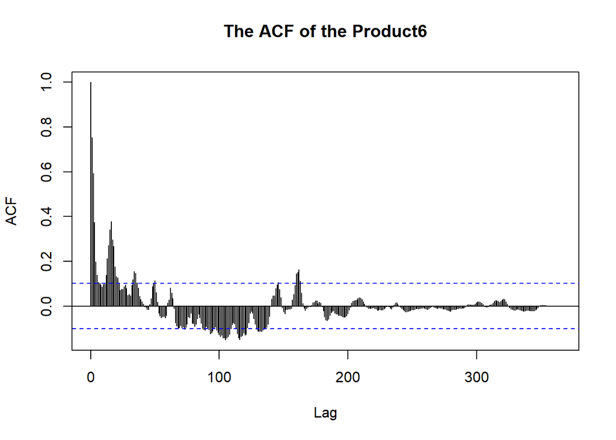

```r
acf(product6_data$sold_count, lag.max = 365, main = "The ACF of the Product6")
```

There are high and decreasing autocorrelation values for recent lags ,so there is a trend in sales data of product 6.There are significant autocorrelation around lag 16.

## ANALYSIS of Product7

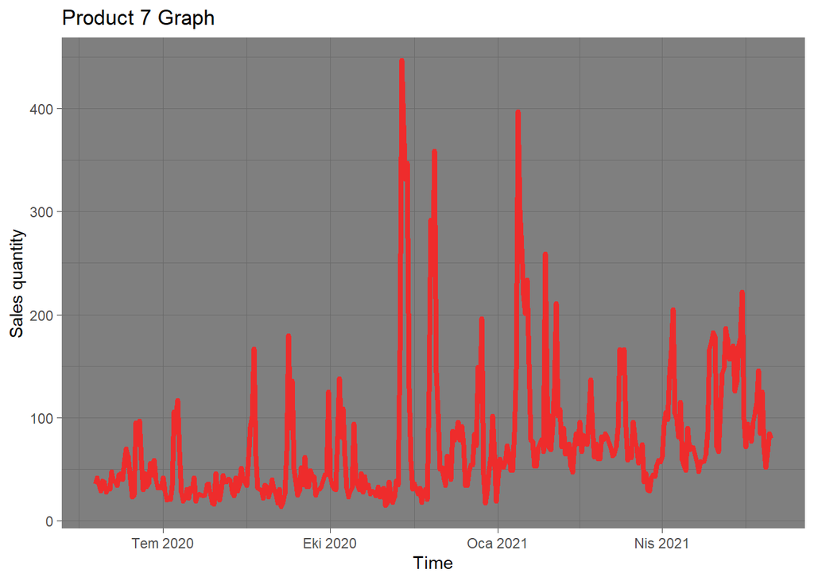

```r
ggplot(product7_data, aes(x = event_date, y = sold_count)) +
    geom_line(colour = "firebrick2", size = 1.5) + labs(title = "Product 7 Graph",
    x = "Time", y = "Sales quantity") + theme_dark()
```

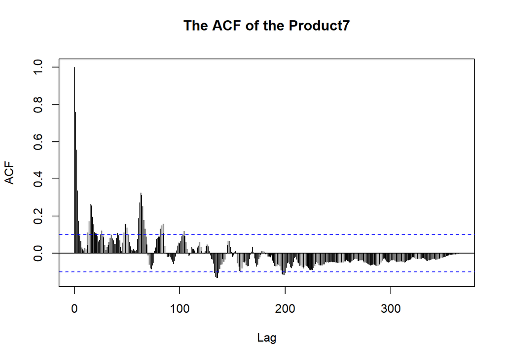

```r
acf(product7_data$sold_count, lag.max = 365, main = "The ACF of the Product7")
```

There are high and decreasing autocorrelation values for recent lags ,so there is a trend in sales data of product 7. There are significant autocorrelation around lag 15.

## ANALYSIS of Product8

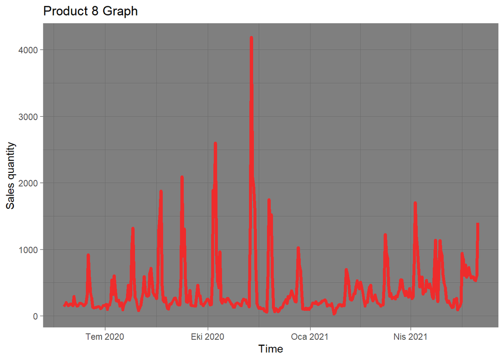

```r
ggplot(product8_data, aes(x = event_date, y = sold_count)) +
    geom_line(colour = "firebrick2", size = 1.5) + labs(title = "Product 8 Graph",
    x = "Time", y = "Sales quantity") + theme_dark()
```

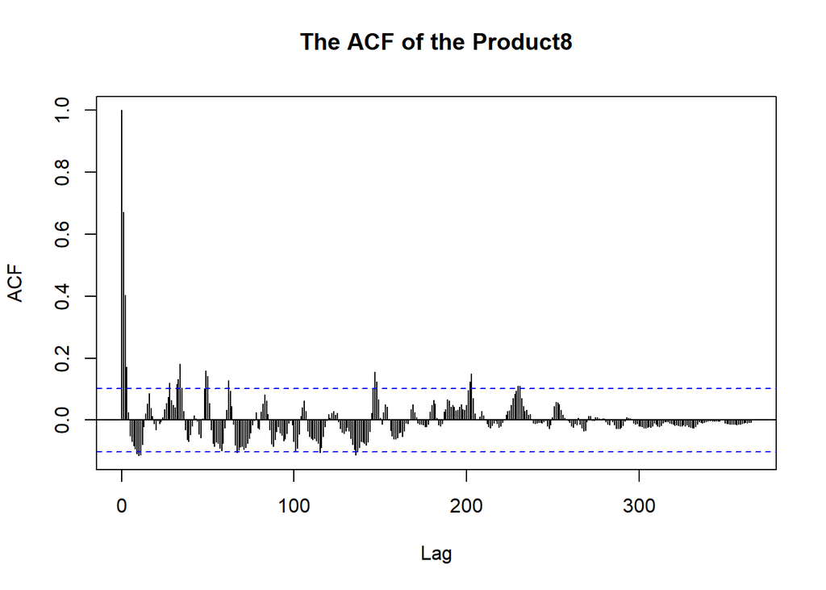

```r
acf(product8_data$sold_count, lag.max = 365, main = "The ACF of the Product8")
```

There are high and decreasing autocorrelation values for recent lags ,so there is a trend in sales data of product 8.

## ANALYSIS of Product9

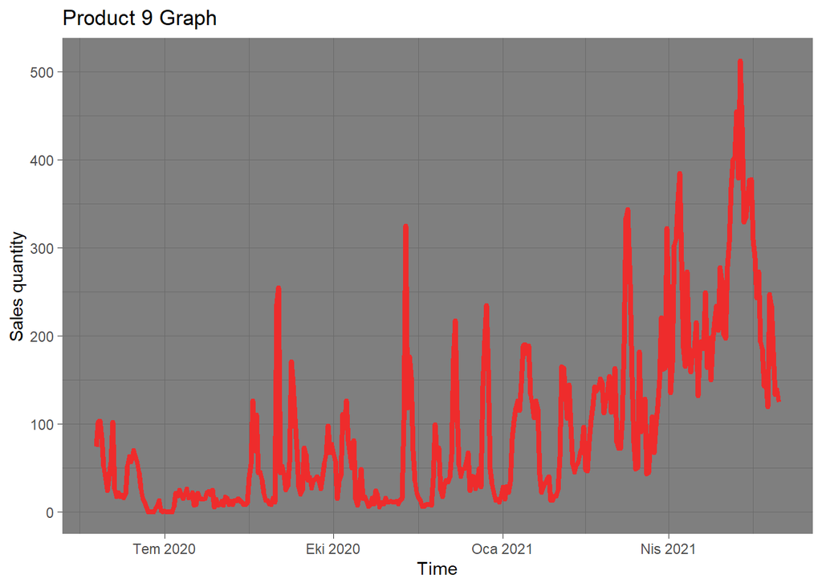

```r
ggplot(product9_data, aes(x = event_date, y = sold_count)) +
    geom_line(colour = "firebrick2", size = 1.5) + labs(title = "Product 9 Graph",
    x = "Time", y = "Sales quantity") + theme_dark()
```

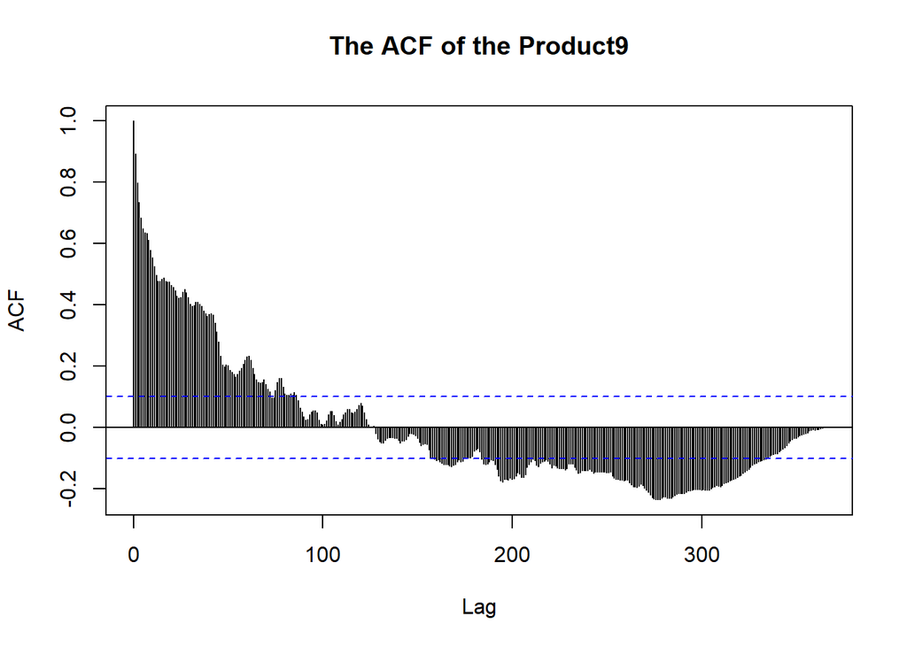

```r
acf(product9_data$sold_count, lag.max = 365, main = "The ACF of the Product9")
```

There are high and decreasing autocorrelation values for many recent lags ,so there is a trend in sales data of product 9.The decrease in the initial lags indicates the trend, but since this decrease is for many lags, we understand that the trend in sales values is long time period.

## Decomposing at Daily Level

In general, the sales values of all products include trend or seasonality.Therefore, none of them are stationary.We need to decomposition to make them stationary.Firstly,we did decomposition at daily level.

```r
product1_ts <- ts(product1_data$sold_count, start = as.Date("2020-05-25"),
    end = as.Date("2021-05-31"), frequency = 7)
product2_ts <- ts(product2_data$sold_count, start = as.Date("2020-05-25"),
    end = as.Date("2021-05-31"), frequency = 7)
product3_ts <- ts(product3_data$sold_count, start = as.Date("2020-05-25"),
    end = as.Date("2021-05-31"), frequency = 7)
product4_ts <- ts(product4_data$sold_count, start = as.Date("2020-05-25"),
    end = as.Date("2021-05-31"), frequency = 7)
product5_ts <- ts(product5_data$sold_count, start = as.Date("2020-05-25"),
    end = as.Date("2021-05-31"), frequency = 7)
product6_ts <- ts(product6_data$sold_count, start = as.Date("2020-05-25"),
    end = as.Date("2021-05-31"), frequency = 7)
product7_ts <- ts(product7_data$sold_count, start = as.Date("2020-05-25"),
    end = as.Date("2021-05-31"), frequency = 7)
product8_ts <- ts(product8_data$sold_count, start = as.Date("2020-05-25"),
    end = as.Date("2021-05-31"), frequency = 7)
product9_ts <- ts(product9_data$sold_count, start = as.Date("2020-05-25"),
    end = as.Date("2021-05-31"), frequency = 7)
product1_dec_daily <- decompose(x = product1_ts, type = "additive")
product2_dec_daily <- decompose(x = product2_ts, type = "additive")
product3_dec_daily <- decompose(x = product3_ts, type = "additive")
product4_dec_daily <- decompose(x = product4_ts, type = "additive")
product5_dec_daily <- decompose(x = product5_ts, type = "additive")
product6_dec_daily <- decompose(x = product6_ts, type = "additive")
product7_dec_daily <- decompose(x = product7_ts, type = "additive")
product8_dec_daily <- decompose(x = product8_ts, type = "additive")
product9_dec_daily <- decompose(x = product9_ts, type = "additive")
```

ACF plot of random component of products that are decomposed at daily level:

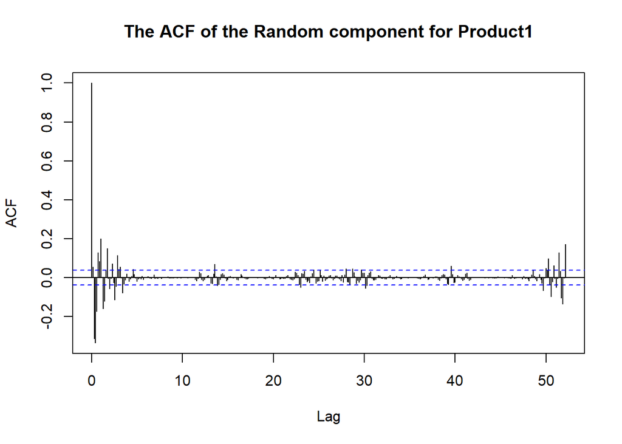

```r
acf(product1_dec_daily$random, na.action = na.pass, lag.max = 365,
    main = "The ACF of the Random component for Product1")
```

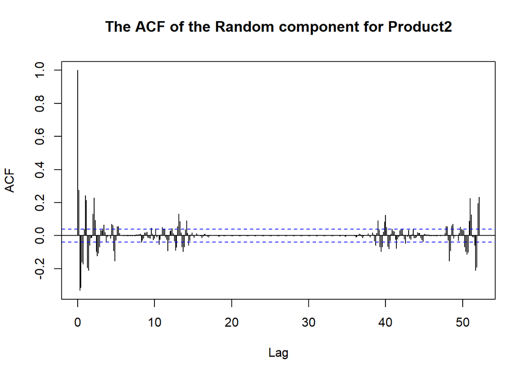

```r
acf(product2_dec_daily$random, na.action = na.pass, lag.max = 365,
    main = "The ACF of the Random component for Product2")
```

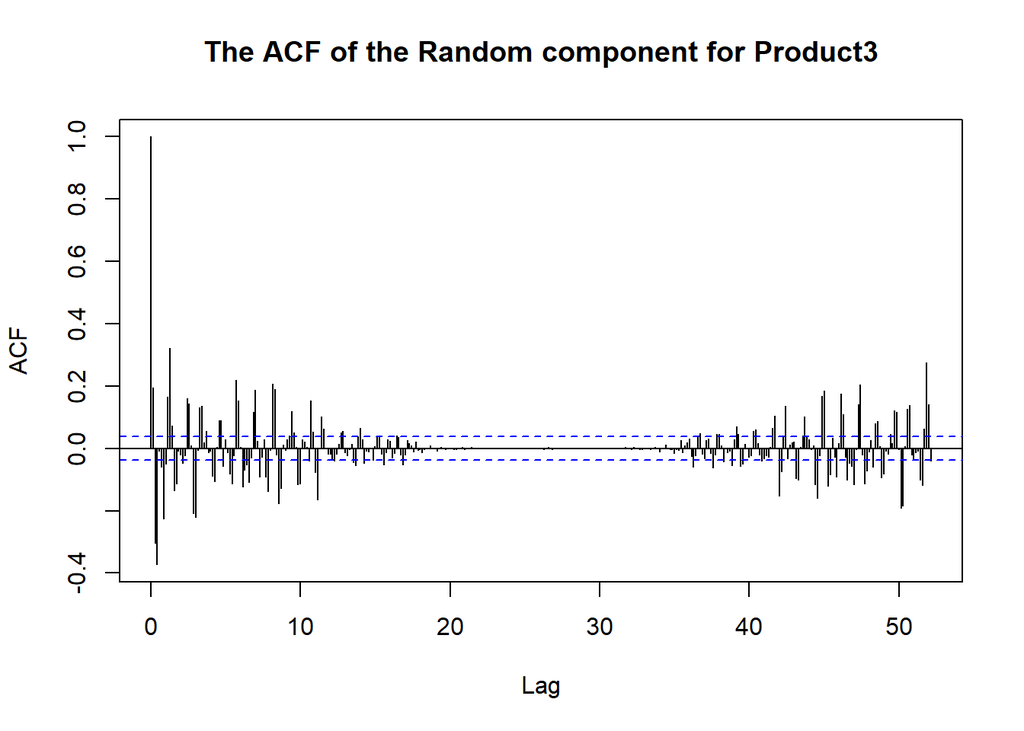

```r
acf(product3_dec_daily$random, na.action = na.pass, lag.max = 365,
    main = "The ACF of the Random component for Product3")
```

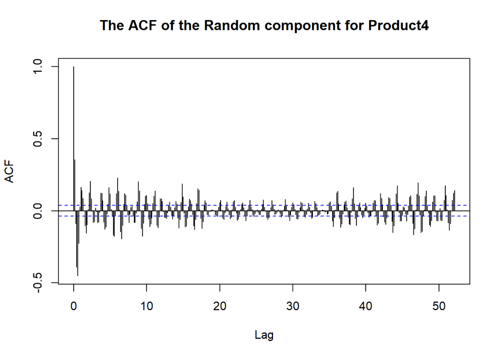

```r
acf(product4_dec_daily$random, na.action = na.pass, lag.max = 365,
    main = "The ACF of the Random component for Product4")
```

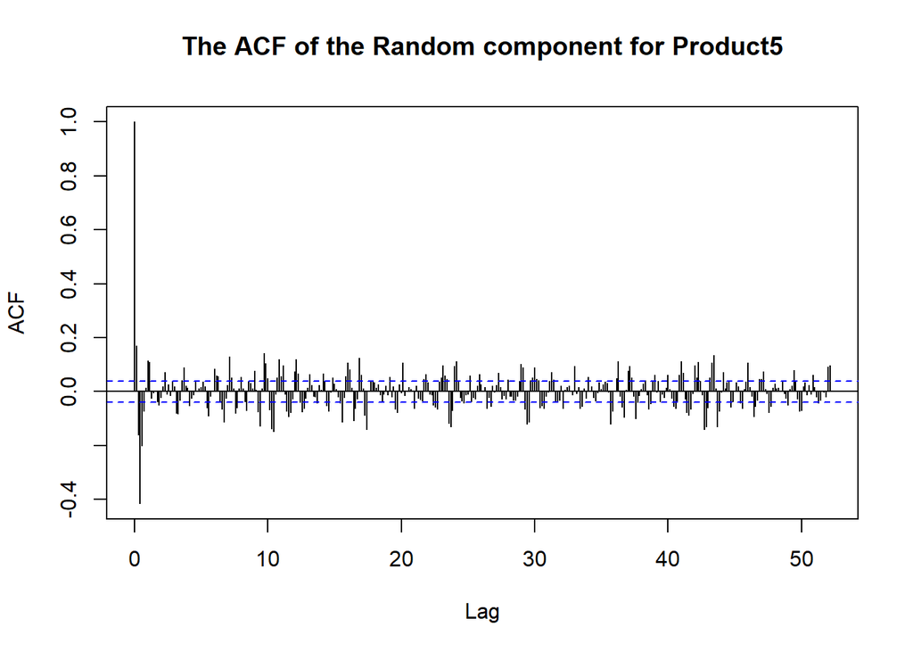

```r
acf(product5_dec_daily$random, na.action = na.pass, lag.max = 365,
    main = "The ACF of the Random component for Product5")
```

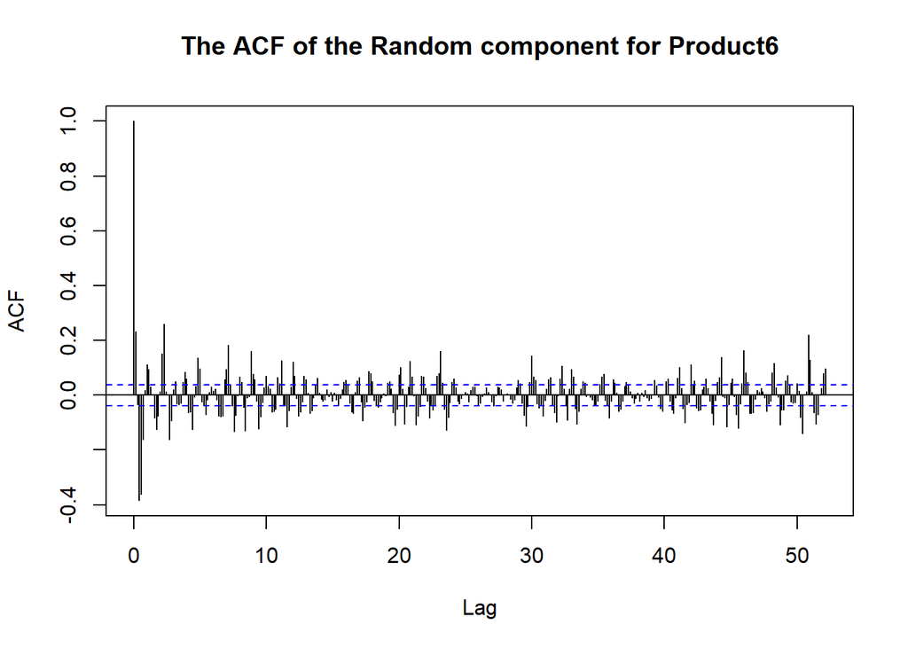

```r
acf(product6_dec_daily$random, na.action = na.pass, lag.max = 365,
    main = "The ACF of the Random component for Product6")
```

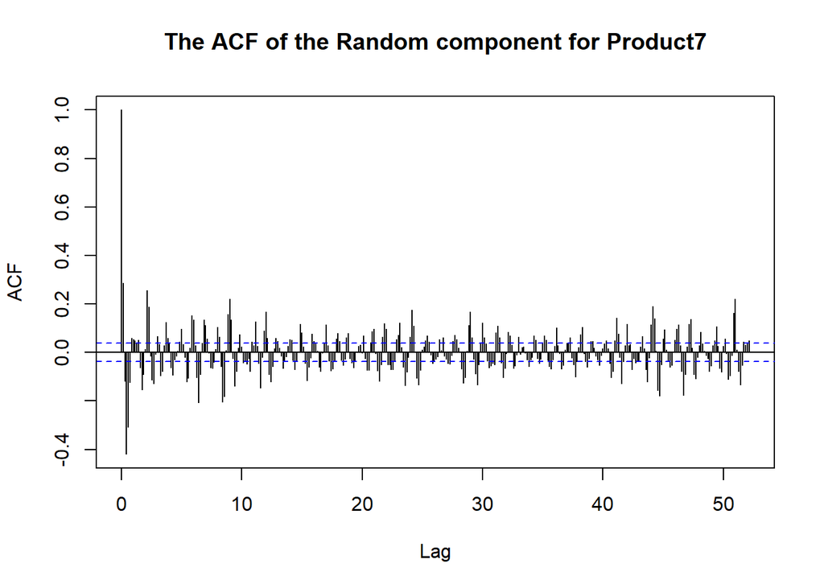

```r
acf(product7_dec_daily$random, na.action = na.pass, lag.max = 365,
    main = "The ACF of the Random component for Product7")
```

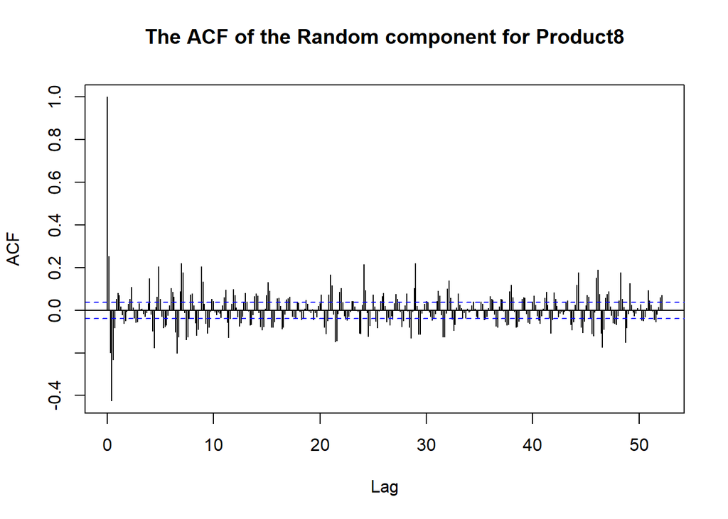

```r
acf(product8_dec_daily$random, na.action = na.pass, lag.max = 365,
    main = "The ACF of the Random component for Product8")
```

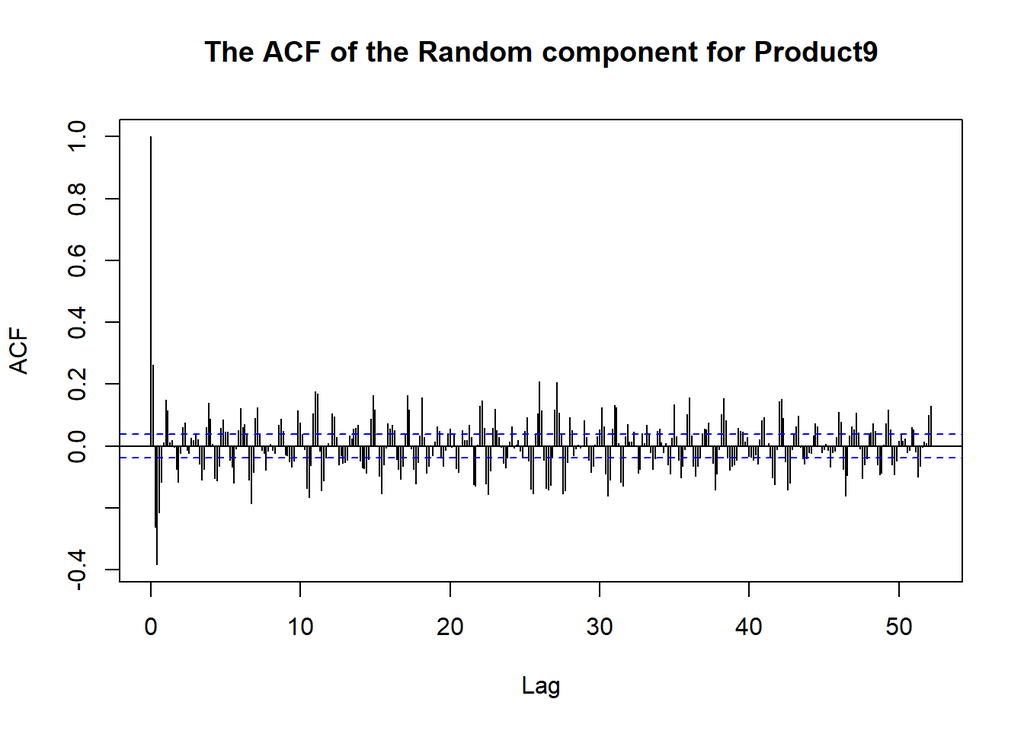

```r
acf(product9_dec_daily$random, na.action = na.pass, lag.max = 365,
    main = "The ACF of the Random component for Product9")
```

There are still high autocorrelation values but they are generally purified from trend and seasonality.

```r
summary(ur.kpss(product1_dec_daily$random))
```

```
##
## #######################
## # KPSS Unit Root Test #
## #######################
##
## Test is of type: mu with 9 lags.
##
## Value of test-statistic is: 0.0018
##
## Critical value for a significance level of:
##                 10pct  5pct 2.5pct  1pct
## critical values 0.347 0.463  0.574 0.739
```

```r
summary(ur.kpss(product2_dec_daily$random))
```

```
##
## #######################
## # KPSS Unit Root Test #
## #######################
##
## Test is of type: mu with 9 lags.
##
## Value of test-statistic is: 0.0041
##
## Critical value for a significance level of:
##                 10pct  5pct 2.5pct  1pct
## critical values 0.347 0.463  0.574 0.739
```

```r
summary(ur.kpss(product3_dec_daily$random))
```

```
##
## #######################
## # KPSS Unit Root Test #
## #######################
##
## Test is of type: mu with 9 lags.
##
## Value of test-statistic is: 0.0044
##
## Critical value for a significance level of:
##                 10pct  5pct 2.5pct  1pct
## critical values 0.347 0.463  0.574 0.739
```

```r
summary(ur.kpss(product4_dec_daily$random))
```

```
##
## #######################
## # KPSS Unit Root Test #
## #######################
##
## Test is of type: mu with 9 lags.
##
## Value of test-statistic is: 0.0018
##
## Critical value for a significance level of:
##                 10pct  5pct 2.5pct  1pct
## critical values 0.347 0.463  0.574 0.739
```

```r
summary(ur.kpss(product5_dec_daily$random))
```

```
##
## #######################
## # KPSS Unit Root Test #
## #######################
##
## Test is of type: mu with 9 lags.
##
## Value of test-statistic is: 0.0019
##
## Critical value for a significance level of:
##                 10pct  5pct 2.5pct  1pct
## critical values 0.347 0.463  0.574 0.739
```

```r
summary(ur.kpss(product6_dec_daily$random))
```

```
##
## #######################
## # KPSS Unit Root Test #
## #######################
##
## Test is of type: mu with 9 lags.
##
## Value of test-statistic is: 0.0018
##
## Critical value for a significance level of:
##                 10pct  5pct 2.5pct  1pct
## critical values 0.347 0.463  0.574 0.739
```

```r
summary(ur.kpss(product7_dec_daily$random))
```

```
##
## #######################
## # KPSS Unit Root Test #
## #######################
##
## Test is of type: mu with 9 lags.
##
## Value of test-statistic is: 0.0018
##
## Critical value for a significance level of:
##                 10pct  5pct 2.5pct  1pct
## critical values 0.347 0.463  0.574 0.739
```

```r
summary(ur.kpss(product8_dec_daily$random))
```

```
##
## #######################
## # KPSS Unit Root Test #
## #######################
##
## Test is of type: mu with 9 lags.
##
## Value of test-statistic is: 0.0019
##
## Critical value for a significance level of:
##                 10pct  5pct 2.5pct  1pct
## critical values 0.347 0.463  0.574 0.739
```

```r
summary(ur.kpss(product9_dec_daily$random))
```

```
##
## #######################
## # KPSS Unit Root Test #
## #######################
##
## Test is of type: mu with 9 lags.
##
## Value of test-statistic is: 0.0031
##
## Critical value for a significance level of:
##                 10pct  5pct 2.5pct  1pct
## critical values 0.347 0.463  0.574 0.739
```

The unit root tests suggest that the random components are stationary.

## Decomposing at Weekly Level

After daily decomposition,we did decomposition at weekly level.While doing the weekly decomposition, we first found the weekly mean of the daily values.

```r
weekly_product1_data = product1_data[, list(weekly_mean_sold_count = mean(sold_count,
    na.rm = T)), by = list(week(event_date), year(event_date))]

weekly_product2_data = product2_data[, list(weekly_mean_sold_count = mean(sold_count,
    na.rm = T)), by = list(week(event_date), year(event_date))]

weekly_product3_data = product3_data[, list(weekly_mean_sold_count = mean(sold_count,
    na.rm = T)), by = list(week(event_date), year(event_date))]

weekly_product4_data = product4_data[, list(weekly_mean_sold_count = mean(sold_count,
    na.rm = T)), by = list(week(event_date), year(event_date))]

weekly_product5_data = product5_data[, list(weekly_mean_sold_count = mean(sold_count,
    na.rm = T)), by = list(week(event_date), year(event_date))]

weekly_product6_data = product6_data[, list(weekly_mean_sold_count = mean(sold_count,
    na.rm = T)), by = list(week(event_date), year(event_date))]

weekly_product7_data = product7_data[, list(weekly_mean_sold_count = mean(sold_count,
    na.rm = T)), by = list(week(event_date), year(event_date))]

weekly_product8_data = product8_data[, list(weekly_mean_sold_count = mean(sold_count,
    na.rm = T)), by = list(week(event_date), year(event_date))]

weekly_product9_data = product9_data[, list(weekly_mean_sold_count = mean(sold_count,
    na.rm = T)), by = list(week(event_date), year(event_date))]

weekly_product9_data
```

```
##     week year weekly_mean_sold_count
##  1:   22 2021             144.750000
##  2:   21 2021             181.571429
##  3:   20 2021             317.714286
##  4:   19 2021             407.285714
##  5:   18 2021             288.000000
##  6:   17 2021             210.857143
##  7:   16 2021             190.142857
##  8:   15 2021             191.000000
##  9:   14 2021             277.142857
## 10:   13 2021             195.000000
## 11:   12 2021              81.000000
## 12:   11 2021              99.428571
## 13:   10 2021             196.428571
## 14:    9 2021             129.714286
```

[output cut: 42 more lines]

Graphs of weekly mean sold counts of products:

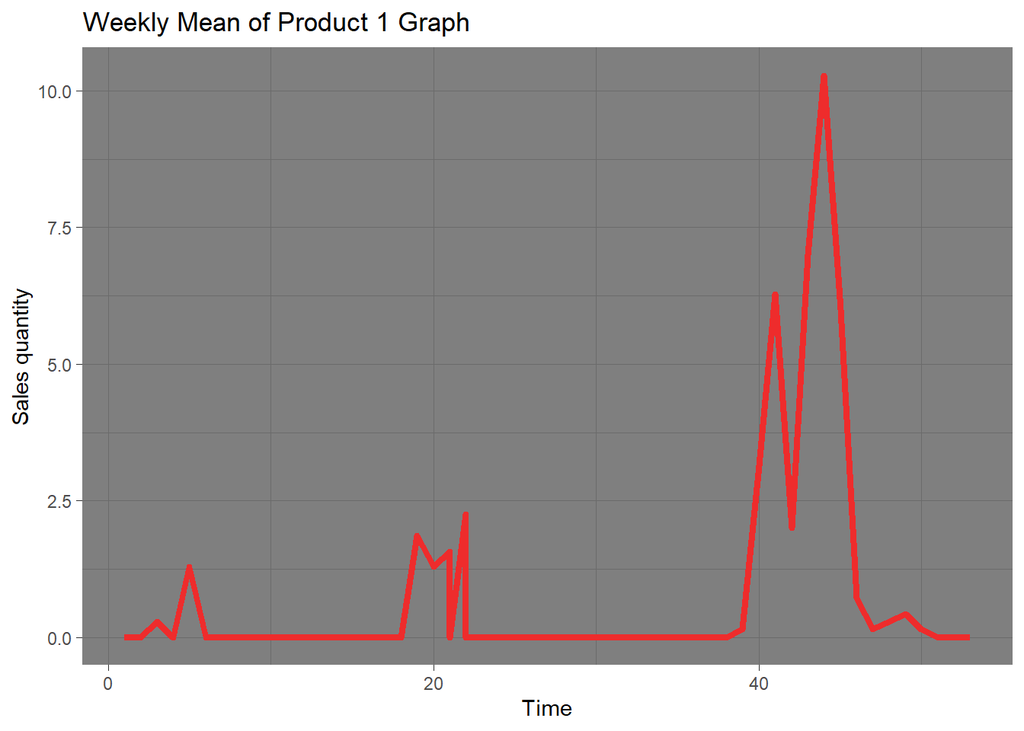

```r
ggplot(weekly_product1_data, aes(x = week, y = weekly_mean_sold_count)) +
    geom_line(colour = "firebrick2", size = 1.5) + labs(title = "Weekly Mean of Product 1 Graph",
    x = "Time", y = "Sales quantity") + theme_dark()
```

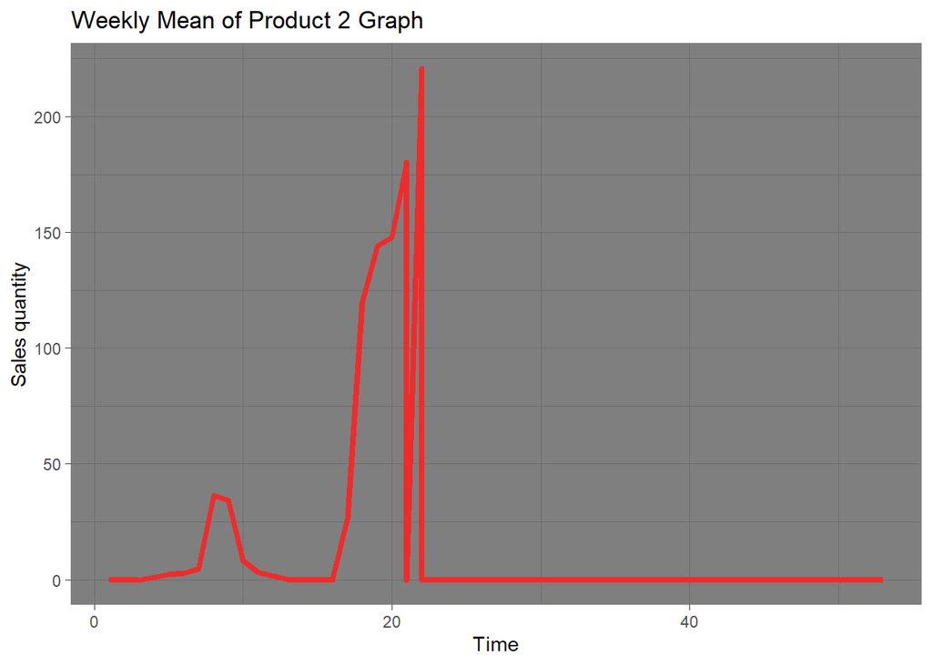

```r
ggplot(weekly_product2_data, aes(x = week, y = weekly_mean_sold_count)) +
    geom_line(colour = "firebrick2", size = 1.5) + labs(title = "Weekly Mean of Product 2 Graph",
    x = "Time", y = "Sales quantity") + theme_dark()
```

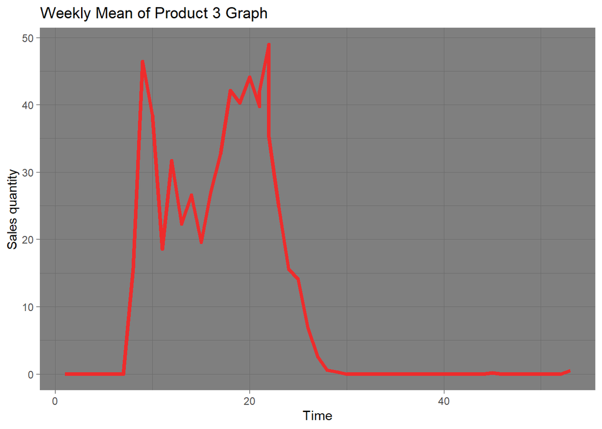

```r
ggplot(weekly_product3_data, aes(x = week, y = weekly_mean_sold_count)) +
    geom_line(colour = "firebrick2", size = 1.5) + labs(title = "Weekly Mean of Product 3 Graph",
    x = "Time", y = "Sales quantity") + theme_dark()
```